# Cell-cycle modeling: iPSC human cell lines

Joyce Hsiao

2016-01-28

```r
library(qtlcharts)
library(CountClust)
library(parallel)
library(cellcycleR)
library(data.table)
library(binhf)
library(vioplot)
library(limma)
library(readxl)
library(Humanzee)
library(mygene)
library(knitr)
```

## Background and objectives

We fit the sinusoidal model on iPSC scRNA-seq data, one individual at a time. We also compare our fitting results with estimates from an ad hoc approach ([Macosko2015](http://www.ncbi.nlm.nih.gov/pubmed/26000488)) which computes phase-specific scores (G1/S, S, G2/M, M, M/G1) for each cell and classify cells based on the highest scoring phase.

The data is not yet publicly available, but you can check out [John Blischak’s website](http://jdblischak.github.io/singleCellSeq/analysis/) for the description of experiment protocol, and results of preliminary data analyses.

## Data prepration

### Import final batch-corrected iPSC data

```r
molecules_final <- read.table("../data/gilad-2015/molecules-final.txt",
                              header = TRUE,
                              stringsAsFactors = FALSE)
anno_filter <- read.table("../data/gilad-2015/annotation-filter.txt",
                          header = TRUE,
                          stringsAsFactors = FALSE)
dim(molecules_final)
```

```
## [1] 12192   560
```

```r
table(anno_filter$individual)
```

```
##
## NA19098 NA19101 NA19239
##     141     199     220
```

Extract only data of one individual

```r
molecules_final_subset <- molecules_final[ , anno_filter$individual == "NA19239"]
dim(molecules_final_subset)
```

```
## [1] 12192   220
```

```r
molecules_final_subset <- molecules_final_subset
```

Import cell-cycle genes

```r
cellcycle_genes <- read.table("../data/gilad-2015/cellcyclegenes.txt",
                               header = TRUE,
                               sep = "\t",
                               stringsAsFactors = FALSE)
colnames(cellcycle_genes) <- c("G1.S","S","G2","G2.M","M.G1")
```

Extract only cell-cycle genes

```r
which_cell_cycle <- which (rownames(molecules_final_subset) %in% unlist(cellcycle_genes))
cycle_data <- t(molecules_final_subset[which_cell_cycle, ])
dim(cycle_data)
```

```
## [1] 220 536
```

Standardize expression levels into z-scores for for gene. This step is for easy visualization of expression levels in plots.

```r
cycle_data_normed <- apply(cycle_data, 2,
                            function(x)  return (x-mean(x))/sd(x))
```

## Cell-cycle score based on Macosko2015

Compute cell-phase score and assign phases.

```r
cell_phase_score <- cell_phase_assign(cellcycle_genes, t(cycle_data_normed) )
head(cell_phase_score)
```

```
##            [,1]       [,2]       [,3]        [,4]       [,5]
## [1,] -1.7618461  0.5418291  0.5298174  0.49776079  0.5679000
## [2,] -0.3110571  1.2986354  0.3402565 -1.17762589 -0.9714712
## [3,]  1.5114554 -0.3177240  0.5672613 -1.24509448 -1.0220431
## [4,] -0.9742465 -0.7847222  1.3234617  1.49094592 -0.4610453
## [5,] -0.2767341  1.3870010 -0.7925593 -0.07399359 -1.2159141
## [6,] -1.0674264  0.6402786  0.8062675  1.03350422 -1.9145531
```

```r
cell_phase <- apply( cell_phase_score,
                      1, function(x) colnames(cellcycle_genes)[which.max(x)])
```

## Fitting on cell-cycle gens

```r
if (file.exists("../rdas/yoav_cycleR_cellcycle_genes-2016-01-28/cellorder-ipsc-2016-01-28.rda")) {
    load("../rdas/yoav_cycleR_cellcycle_genes-2016-01-28/cellorder-ipsc-2016-01-28.rda")
} else {
results <- sin_cell_ordering_class(cycle_data_normed,
                                   celltime_levels = 300,
                                   num_iter = 300)
save(results,
     file ="../rdas/yoav_cycleR_cellcycle_genes-2016-01-28/cellorder-ipsc-2016-01-28.rda")
}
str(results)
```

```
## List of 6
##  $ cell_times      : num [1:220] 5.758 2.753 4.287 0.357 3.257 ...
##  $ amp             : num [1:536] 0.0689 0.256 0.1392 0.0721 0.3354 ...
##  $ phi             : num [1:536] 1.312 0.746 1.426 1.245 1.873 ...
##  $ sigma           : num [1:536] 0.434 0.828 0.647 0.546 1.456 ...
##  $ loglik          : num -148111
##  $ signal_intensity: num [1:220, 1:300] -698 -781 -687 -667 -859 ...
```

Post-processing of cell-phase order.

```r
cell_order_full <- cell_ordering_full(results$signal_intensity, dim(molecules_final)[2])
str(cell_order_full)
```

```
##  num [1:220(1d)] 5.625 2.732 4.413 0.226 2.972 ...
```

### Model estimates

We look at the plots of the amplitudes, phases and the non signal variation of the genes.

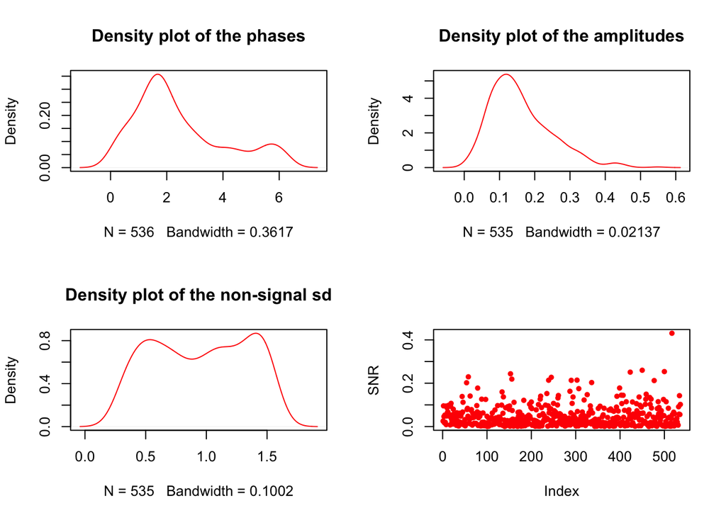

```r
amp_genes <- results$amp
sd_genes <- results$sigma
phi_genes <- results$phi

par(mfrow=c(2,2))
plot(density(phi_genes), col="red",
     main="Density plot of the phases")
plot(density(amp_genes[-which.max(amp_genes)]), col="red",
     main="Density plot of the amplitudes")
plot(density(sd_genes[-which.max(sd_genes)]), col="red",
     main="Density plot of the non-signal sd")

ESS <- amp_genes^2
RSS <- sd_genes^2
SNR <- ESS/RSS
plot(SNR, col="red", pch=20, lwd=1)
```

### Re-ordered expression pattern

We extract the genes with high SNR - these are more likely to be sinusoidal.

```r
sum(SNR > .1)
```

```
## [1] 60
```

```r
top_genes <- which(SNR > .1)

cut <- .05
    top_genes <- which(SNR > cut)
    new_cell_order <- binhf::shift(order(cell_order_full), 130, dir = "right")
    iplotCurves(t(cycle_data_normed[new_cell_order, top_genes]),
                chartOpts = list(title = paste("SNR > ", cut)))
```

```
## Set screen size to height=700 x width=1000
```

[interactive chart not shown]

```r
cut <- .1
    top_genes <- which(SNR > cut)
    new_cell_order <- binhf::shift(order(cell_order_full), 130, dir = "right")
    iplotCurves(t(cycle_data_normed[new_cell_order, top_genes]),
                chartOpts = list(title = paste("SNR > ", cut)))
```

[interactive chart not shown]

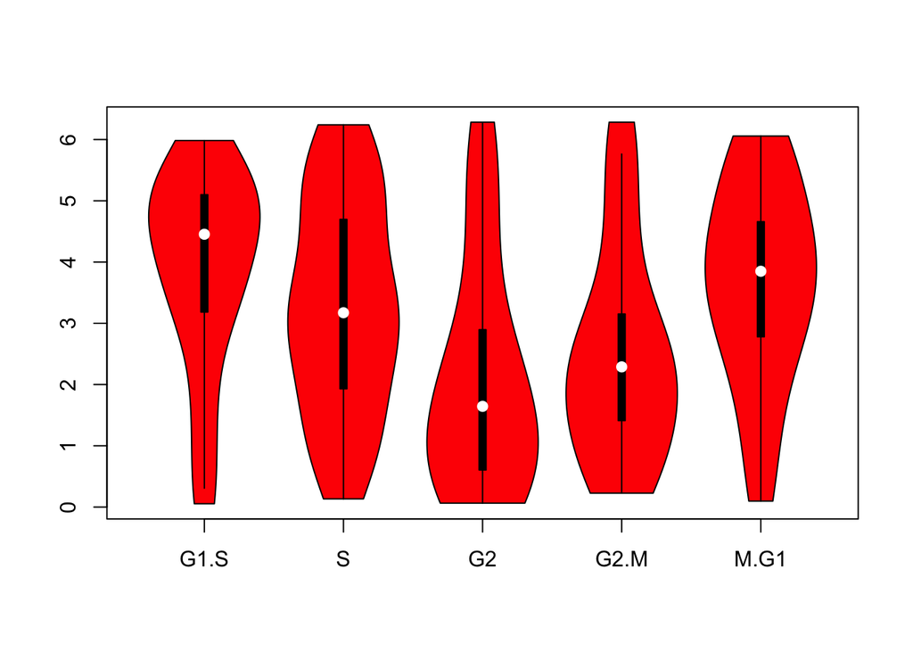

```r
vioplot(cell_order_full[which(cell_phase=="G1.S")],
        cell_order_full[which(cell_phase=="S")],
        cell_order_full[which(cell_phase=="G2")],
        cell_order_full[which(cell_phase=="G2.M")],
        cell_order_full[which(cell_phase=="M.G1")],
        names=c("G1.S","S","G2","G2.M","M.G1"),
        col="red")
```

```r
iplotCurves(t(cycle_data_normed[c(which(cell_phase=="G1"),
                                which(cell_phase=="S"),
                                which(cell_phase=="G2"),
                                which(cell_phase=="G2.M"),
                                which(cell_phase=="M.G1")), top_genes]))
```

[interactive chart not shown]

## Re-fitting on high SNR genes

We extract the high SNR genes as they seem to have sinusoidal patterns and repeat the procedure again.

```r
snr_high_indices <- which(SNR > .1)
cycle_data_normed_high_snr <- cycle_data_normed[ ,snr_high_indices]
dim(cycle_data_normed_high_snr)
```

```
## [1] 220  60
```

Modeing fitting…

```r
if (file.exists("../rdas/yoav_cycleR_cellcycle_genes-2016-01-28/cellorder-ipsc-2016-01-28-high-snr.rda")) {
    load("../rdas/yoav_cycleR_cellcycle_genes-2016-01-28/cellorder-ipsc-2016-01-28-high-snr.rda")
} else {
results_high_snr <- sin_cell_ordering_class(cycle_data_normed_high_snr,
                                        celltime_levels = 300, num_iter=200)
save(results_high_snr,
     file = "../rdas/yoav_cycleR_cellcycle_genes-2016-01-28/cellorder-ipsc-2016-01-28-high-snr.rda")
}
```

Post-processing

```r
cell_order_full <- cell_ordering_full(results_high_snr$signal_intensity,
                                      dim(cycle_data_normed_high_snr)[2])
```

### Model estimates

We plot the same features as above and check for the robustness. We needed to shift the cell order so as to compare with previous plot on all genes as the method is non-identifiable upto a rotation.

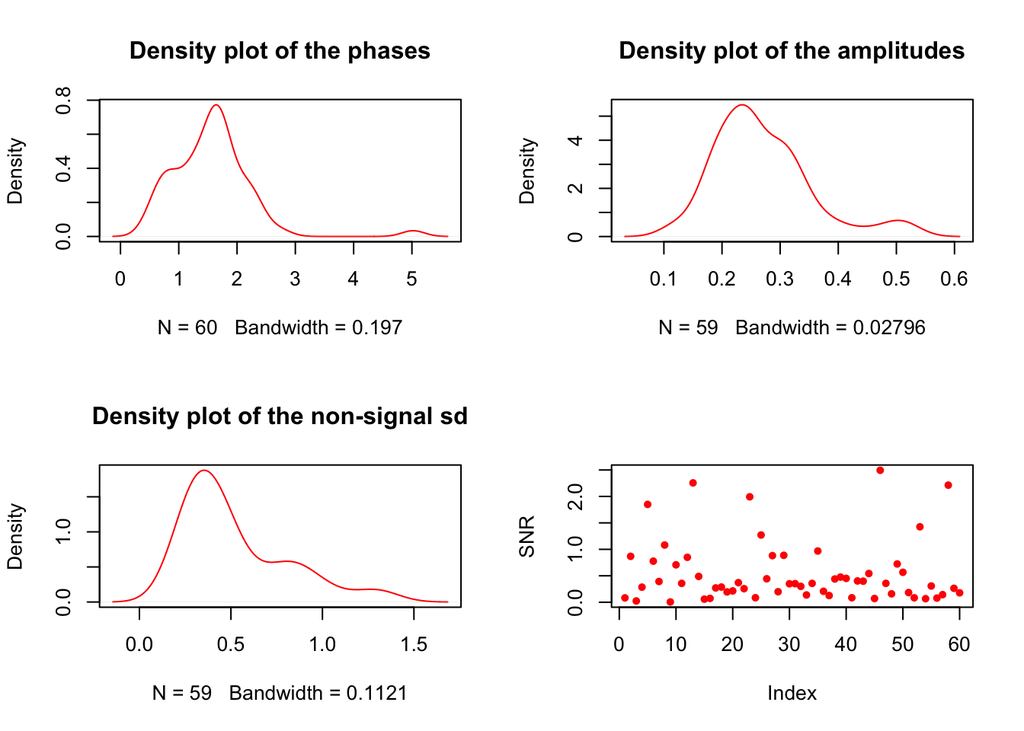

```r
amp_genes <- results_high_snr$amp;
sd_genes <- results_high_snr$sigma;
phi_genes <- results_high_snr$phi;

par(mfrow = c(2,2))
plot(density(phi_genes), col="red", main="Density plot of the phases")
plot(density(amp_genes[-which.max(amp_genes)]), col="red", main="Density plot of the amplitudes")
plot(density(sd_genes[-which.max(sd_genes)]), col="red", main="Density plot of the non-signal sd")

ESS <- amp_genes^2; RSS <- sd_genes^2
SNR <- ESS/RSS;
plot(SNR, col="red", pch=20, lwd=1)
```

### Re-ordered expression patterns

```r
# these html widgets require some adding coding to be
# wrapped inside a loop
# plot_list <- lapply(c(.1, .5, .1), function(cut) {
#     top_genes <- which(SNR > cut)
#     new_cell_order <- binhf::shift(order(cell_order_full), 130, dir = "right")
#     return(iplotCurves(t(cycle_data_normed_high_snr[new_cell_order, top_genes]),
#                 chartOpts = list(title = paste("SNR > ", cut))) )
#
# })
# plot_list <- lapply(plot_list, htmltools::tags$p)
# htmltools::tagList(plot_list)

cut <- .1
    top_genes <- which(SNR > cut)
    new_cell_order <- binhf::shift(order(cell_order_full), 130, dir = "right")
    iplotCurves(t(cycle_data_normed_high_snr[new_cell_order, top_genes]),
                 chartOpts = list(title = paste("SNR > ", cut)))
```

[interactive chart not shown]

```r
cut <- .5
    top_genes <- which(SNR > cut)
    new_cell_order <- binhf::shift(order(cell_order_full), 130, dir = "right")
    iplotCurves(t(cycle_data_normed_high_snr[new_cell_order, top_genes]),
                 chartOpts = list(title = paste("SNR > ", cut)))
```

[interactive chart not shown]

```r
cut <- 1
top_genes <- which(SNR > cut)
new_cell_order <- binhf::shift(order(cell_order_full), 130, dir = "right")
print(iplotCurves(t(cycle_data_normed_high_snr[new_cell_order, top_genes]),
             chartOpts = list(title = paste("SNR > ", cut))) )
```

[output not shown]

The curvees of the top genes show a very string sinusoidal pattern. We compared the estimated cell-order against the assigned cell-phases in Mascoko2015. The violin plot below indicates that 1) most cells are at G1.S or M.G1 phase, a signature of iPSC cells, and 2) our estimated cell-order coincoide with the cell-phase assignment in Mascoko2015.

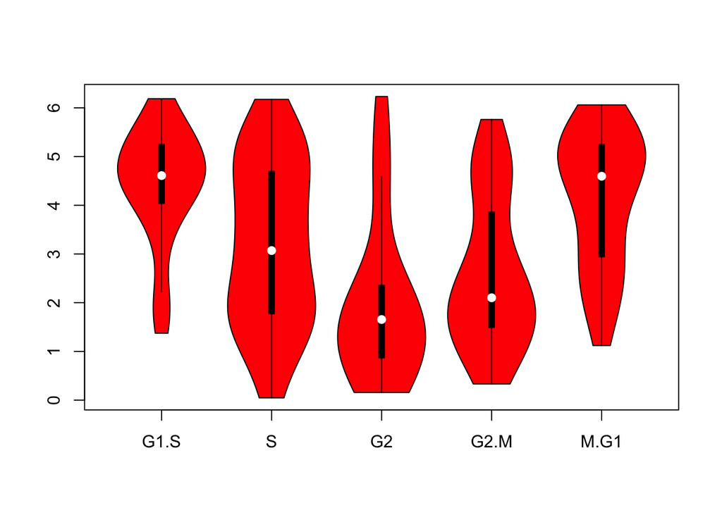

```r
vioplot(cell_order_full[which(cell_phase=="G1.S")],
        cell_order_full[which(cell_phase=="S")],
        cell_order_full[which(cell_phase=="G2")],
        cell_order_full[which(cell_phase=="G2.M")],
        cell_order_full[which(cell_phase=="M.G1")],
        names=c("G1.S","S","G2","G2.M","M.G1"),
        col="red")
```

### Annotation

```r
sinusoidal_gene_names <- colnames(cycle_data_normed_high_snr)
#top_genes <- sinusoidal_gene_names[which(SNR > .5)]
sinusoidal_gene_names_ordered <- sinusoidal_gene_names[order(SNR, decreasing = TRUE)]

gene_query <- queryMany(sinusoidal_gene_names_ordered[1:30],
                        scopes="ensembl.gene",
                        fields=c("name","summary"), species="human")
```

```
## Finished
## Pass returnall=TRUE to return lists of duplicate or missing query terms.
```

```r
kable(as.data.frame(gene_query))
```

| summary | name | query | X_id |
| --- | --- | --- | --- |
| This gene encodes a beta tubulin protein. This protein forms a dimer with alpha tubulin and acts as a structural component of microtubules. Mutations in this gene cause cortical dysplasia, complex, wi… | tubulin beta class I | ENSG00000196230 | 203068 |
| RAN (ras-related nuclear protein) is a small GTP binding protein belonging to the RAS superfamily that is essential for the translocation of RNA and proteins through the nuclear pore complex. The RAN … | RAN, member RAS oncogene family | ENSG00000132341 | 5901 |
| CKS2 protein binds to the catalytic subunit of the cyclin dependent kinases and is essential for their biological function. The CKS2 mRNA is found to be expressed in different patterns through the cel… | CDC28 protein kinase regulatory subunit 2 | ENSG00000123975 | 1164 |
| This gene encodes a DNA topoisomerase, an enzyme that controls and alters the topologic states of DNA during transcription. This nuclear enzyme is involved in processes such as chromosome condensation… | topoisomerase (DNA) II alpha | ENSG00000131747 | 7153 |
| This gene encodes a nuclear protein that is highly conserved in vertebrates. The conserved regions of the protein contain several consensus phosphorylation sites for casein kinase II and cyclin-depend… | nuclear casein kinase and cyclin-dependent kinase substrate 1 | ENSG00000069275 | 64710 |
| At the nuclear envelope, the nuclear lamina and heterochromatin are adjacent to the inner nuclear membrane. The protein encoded by this gene binds DNA and is a component of heterochromatin. This prote… | chromobox 3 | ENSG00000122565 | 11335 |
| The import of proteins into the nucleus is a process that involves at least 2 steps. The first is an energy-independent docking of the protein to the nuclear envelope and the second is an energy-depen… | karyopherin alpha 2 | ENSG00000182481 | 3838 |
| This gene encodes a protein involved in spindle checkpoint function. The encoded protein contains four WD repeat domains and has sequence similarity with the yeast BUB3 protein. Alternate transcriptio… | BUB3 mitotic checkpoint protein | ENSG00000154473 | 9184 |
| The modification of proteins with ubiquitin is an important cellular mechanism for targeting abnormal or short-lived proteins for degradation. Ubiquitination involves at least three classes of enzymes… | ubiquitin conjugating enzyme E2C | ENSG00000175063 | 11065 |
| The protein encoded by this gene is a member of the serine/arginine (SR)-rich family of pre-mRNA splicing factors, which constitute part of the spliceosome. Each of these factors contains an RNA recog… | serine/arginine-rich splicing factor 7 | ENSG00000115875 | 6432 |
| Ribosomes, the organelles that catalyze protein synthesis, consist of a small 40S subunit and a large 60S subunit. Together these subunits are composed of 4 RNA species and approximately 80 structural… | ribosomal protein L13a | ENSG00000142541 | 23521 |
| The protein encoded by this gene is a transcription factor required for T-cell expression of the interleukin 2 gene. It also binds RNA and is an essential component for encapsidation and protein primi… | interleukin enhancer binding factor 2 | ENSG00000143621 | 3608 |
| Cytoplasmic dyneins are large enzyme complexes with a molecular mass of about 1,200 kD. They contain two force-producing heads formed primarily from dynein heavy chains, and stalks linking the heads t… | dynein, light chain, LC8-type 1 | ENSG00000088986 | 8655 |
| This gene encodes a protein that associates with the centromere-kinetochore complex. The protein is a component of the nuclear matrix during the G2 phase of interphase. In late G2 the protein associat… | centromere protein F | ENSG00000117724 | 1063 |
| This gene encodes a member of the cellular heterogeneous nuclear ribonucleoprotein (hnRNP) family. hnRNPs are RNA binding proteins that complex with heterogeneous nuclear RNA (hnRNA) and regulate alte… | synaptotagmin binding, cytoplasmic RNA interacting protein | ENSG00000135316 | 10492 |
| NA | family with sequence similarity 60 member A | ENSG00000139146 | 58516 |
| This gene encodes a transcriptional repressor that interacts with several members of the BCL2 family of proteins. Overexpression of this protein induces apoptosis, which can be suppressed by co-expres… | BCL2-associated transcription factor 1 | ENSG00000029363 | 9774 |
| This gene encodes one of the DNA-unwinding enzymes which prefers partially unwound 3’-tailed substrates and can also unwind partial RNA/DNA and RNA/RNA duplexes in an ATP-dependent fashion. This enzym… | GTPase activating protein (SH3 domain) binding protein 1 | ENSG00000145907 | 10146 |
| This gene encodes a cytoskeleton-associated protein that stabalizes microtubules and plays a role in the regulation of cell division. The encoded protein is itself regulated through phosphorylation at… | cytoskeleton associated protein 2 | ENSG00000136108 | 26586 |
| Centrosome-associated protein E (CENPE) is a kinesin-like motor protein that accumulates in the G2 phase of the cell cycle. Unlike other centrosome-associated proteins, it is not present during interp… | centromere protein E | ENSG00000138778 | 1062 |
| MAD2L1 is a component of the mitotic spindle assembly checkpoint that prevents the onset of anaphase until all chromosomes are properly aligned at the metaphase plate. MAD2L1 is related to the MAD2L2 … | MAD2 mitotic arrest deficient-like 1 (yeast) | ENSG00000164109 | 4085 |
| NA | hematological and neurological expressed 1 | ENSG00000189159 | 51155 |
| The modification of proteins with ubiquitin is an important cellular mechanism for targeting abnormal or short-lived proteins for degradation. Ubiquitination involves at least three classes of enzymes… | ubiquitin conjugating enzyme E2D 3 | ENSG00000109332 | 7323 |
| Initiation of transcription by RNA polymerase II requires the activities of more than 70 polypeptides. The protein that coordinates these activities is transcription factor IID (TFIID), which binds to… | TATA-box binding protein associated factor 9 | ENSG00000085231 | 6880 |
| This gene encodes a protein that belongs to the adenylate kinase family of enzymes. The protein has a nuclear localization and contains Walker A (P-loop) and Walker B motifs and a metal-coordinating r… | adenylate kinase 6 | ENSG00000085231 | 102157402 |
| This gene encodes one of the two B-type lamin proteins and is a component of the nuclear lamina. A duplication of this gene is associated with autosomal dominant adult-onset leukodystrophy (ADLD). Alt… | lamin B1 | ENSG00000113368 | 4001 |
| NA | kinesin family member 20B | ENSG00000138182 | 9585 |
| This gene encodes a member of the aurora kinase subfamily of serine/threonine kinases. The genes encoding the other two members of this subfamily are located on chromosomes 19 and 20. These kinases pa… | aurora kinase B | ENSG00000178999 | 9212 |
| PHIP binds the pleckstrin homology (PH) domain of insulin receptor substrate-1 (IRS1; MIM 147545), modulates insulin signaling, and plays a role in pancreatic beta cell growth and survival (Farhang-Fa… | pleckstrin homology domain interacting protein | ENSG00000146247 | 55023 |
| Microtubules of the eukaryotic cytoskeleton perform essential and diverse functions and are composed of a heterodimer of alpha and beta tubulins. The genes encoding these microtubule constituents belo… | tubulin alpha 1a | ENSG00000167552 | 7846 |
| The protein encoded by this gene is found in the nucleus and is a cofactor of DNA polymerase delta. The encoded protein acts as a homotrimer and helps increase the processivity of leading strand synth… | proliferating cell nuclear antigen | ENSG00000132646 | 5111 |